# chap10_legends

J.H AHN

2022 1 11

### 10.1 Removing the legend

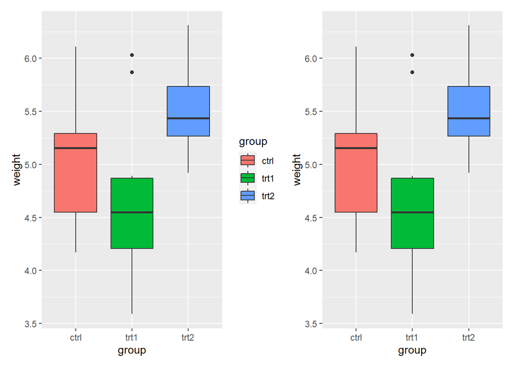

```r
fig_10011 <-
  PlantGrowth %>%
  ggplot(aes(x = group, y = weight, fill = group)) +
  geom_boxplot()

fig_10012 <-
  PlantGrowth %>%
  ggplot(aes(x = group, y = weight, fill = group)) +
  geom_boxplot() +
  guides(fill = "none")

fig_10011 + fig_10012
```

legend를 없애는 다른 방법으로는 `scale_fill_discrete(guide = "none")`를 사용하는 방법과 `theme(legend.position = “none”)를 사용하는 방법이 있다.

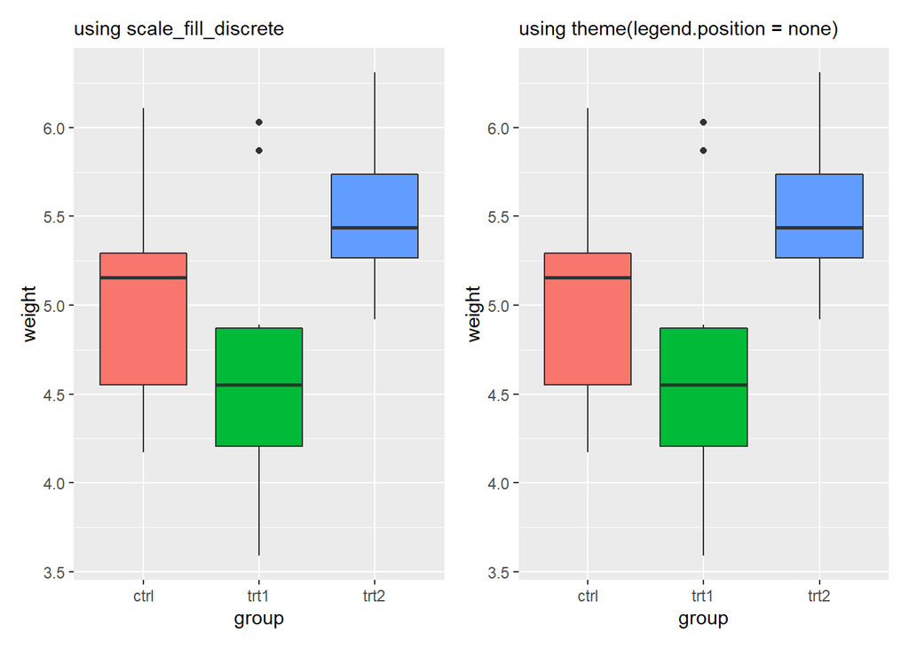

```r
fig_10013 <-
  PlantGrowth %>%
  ggplot(aes(x = group, y = weight, fill = group)) +
  geom_boxplot() +
  scale_fill_discrete(guide = "none") +
  labs(subtitle = "using scale_fill_discrete")

fig_10014 <-
  PlantGrowth %>%
  ggplot(aes(x = group, y = weight, fill = group)) +
  geom_boxplot() +
  theme(legend.position = "none") +
  labs(subtitle = "using theme(legend.position = none)")

fig_10013 + fig_10014
```

### 10.2 Changing the position of a legend

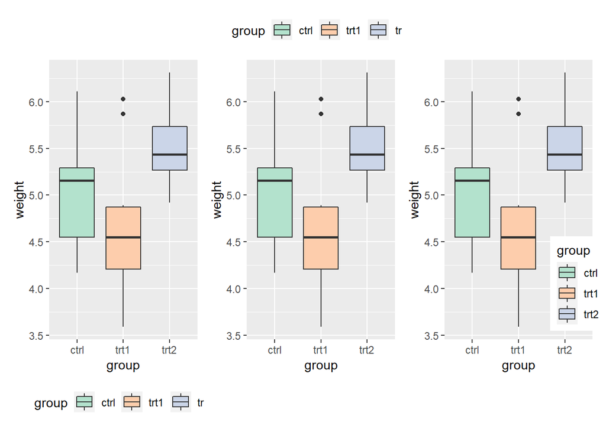

```r
fig_10021 <-
  PlantGrowth %>%
  ggplot(aes(x = group, y = weight, fill = group)) +
  geom_boxplot() +
  scale_fill_brewer(palette = "Pastel2") +
  theme(legend.position = "bottom")

fig_10022 <-
  PlantGrowth %>%
  ggplot(aes(x = group, y = weight, fill = group)) +
  geom_boxplot() +
  scale_fill_brewer(palette = "Pastel2") +
  theme(legend.position = "top")

fig_10023 <-
  PlantGrowth %>%
  ggplot(aes(x = group, y = weight, fill = group)) +
  geom_boxplot() +
  scale_fill_brewer(palette = "Pastel2") +
  theme(legend.position = c(0.9,0.2))


fig_10021 + fig_10022 + fig_10023
```

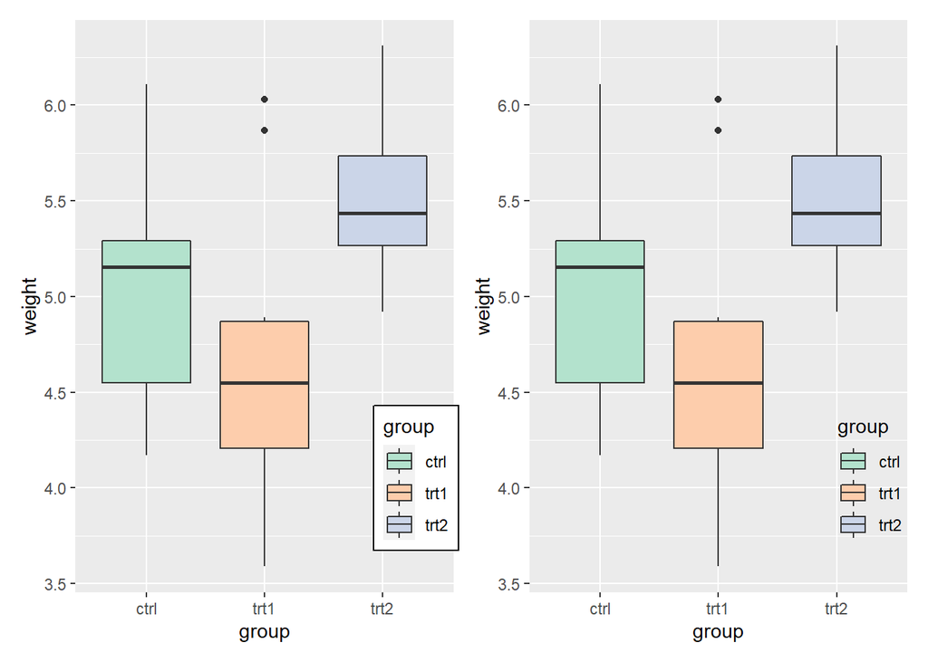

```r
fig_10041 <-
  PlantGrowth %>%
  ggplot(aes(x = group, y = weight, fill = group)) +
  geom_boxplot() +
  scale_fill_brewer(palette = "Pastel2") +
  theme(legend.position = c(0.9, 0.2)) +
  theme(legend.background = element_rect(fill = "#FFFFFF", color = "#000000"))

fig_10042 <-
  PlantGrowth %>%
  ggplot(aes(x = group, y = weight, fill = group)) +
  geom_boxplot() +
  scale_fill_brewer(palette = "Pastel2") +
  theme(legend.position = c(0.9, 0.2)) +
  theme(legend.background = element_blank()) + # Remove overall border
  theme(legend.key = element_blank())          # Remove border around each item

fig_10041 + fig_10042
```

### 10.3 Changing the order of items in a legend

`scale_fill_discrete(limits = ...)`으로 legend의 순서를 바꿀 수 있다.  
하지만 실제 축에서 순서는 바뀌지 않는데 축에서 데이터의 순서까지 바꾸려면 `scale_x_discrete(limits = ...)`을 사용해야 한다.

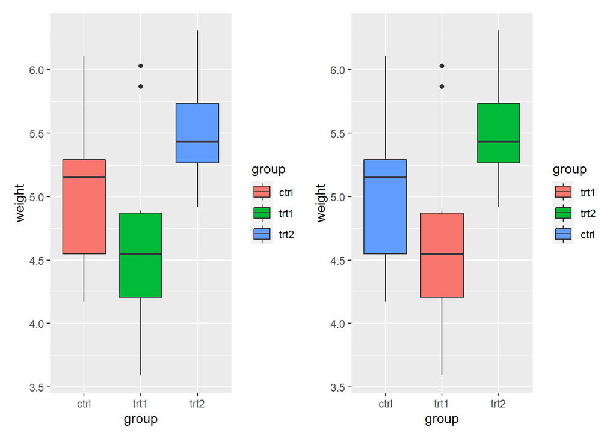

```r
fig_10051 <-
  PlantGrowth %>%
  ggplot(aes(x = group, y = weight, fill = group)) +
  geom_boxplot()

fig_10052 <-
  PlantGrowth %>%
  ggplot(aes(x = group, y = weight, fill = group)) +
  geom_boxplot() +
  scale_fill_discrete(limits = c("trt1", "trt2", "ctrl"))

fig_10051 + fig_10052
```

기본적으로 group은 fill 속성에 따라 mapping되어 있다.  
그래서 `scale_fill_discrete()`를 사용하여 factor level에 따라 색깔이 부여된 것을 변경할 수 있다.  
따라서 다른 `scale_fill_xxx()`함수를 이용하면 그룹별로 맵핑된 속성들을 변경할 수 있다.

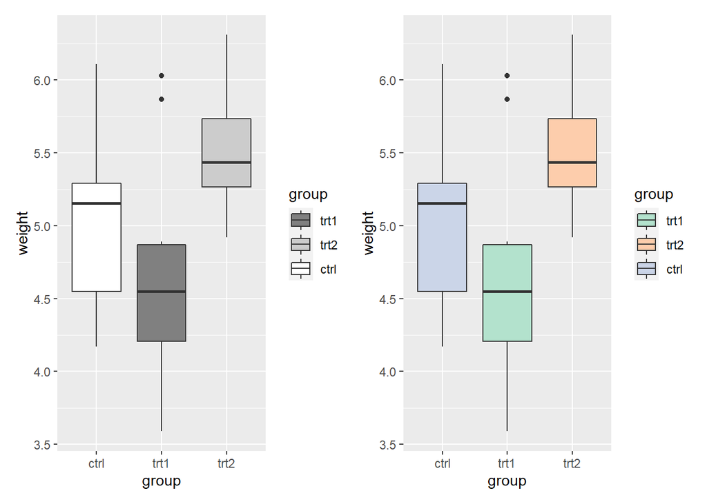

```r
fig_10061 <-
  PlantGrowth %>%
  ggplot(aes(x = group, y = weight, fill = group)) +
  geom_boxplot() +
  scale_fill_grey(start = 0.5, end = 1.0, limits = c("trt1", "trt2", "ctrl"))

fig_10062 <-
  PlantGrowth %>%
  ggplot(aes(x = group, y = weight, fill = group)) +
  geom_boxplot() +
  scale_fill_brewer(palette = "Pastel2", limits = c("trt1", "trt2", "ctrl"))

fig_10061 + fig_10062
```

### 10.4 Reversing the order of items in a legend

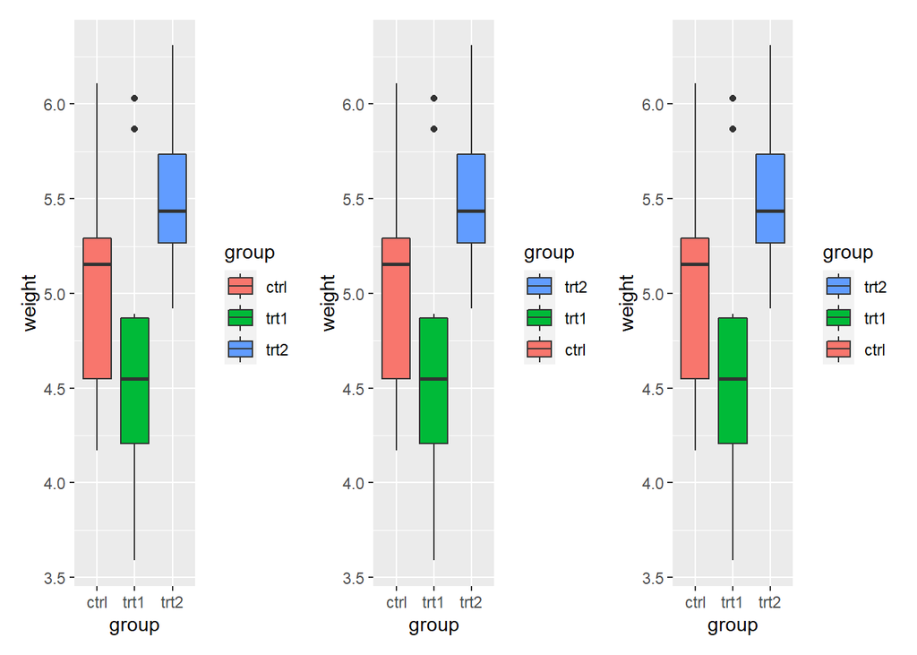

```r
fig_10071 <-
  PlantGrowth %>%
  ggplot(aes(x = group, y = weight, fill = group)) +
  geom_boxplot()

fig_10072 <-
  PlantGrowth %>%
  ggplot(aes(x = group, y = weight, fill = group)) +
  geom_boxplot() +
  guides(fill = guide_legend(reverse = TRUE))

fig_10073 <-
  PlantGrowth %>%
  ggplot(aes(x = group, y = weight, fill = group)) +
  geom_boxplot() +
  scale_fill_hue(guide = guide_legend(reverse = TRUE))

fig_10071 + fig_10072 + fig_10073
```

### 10.5 Changing a legend title

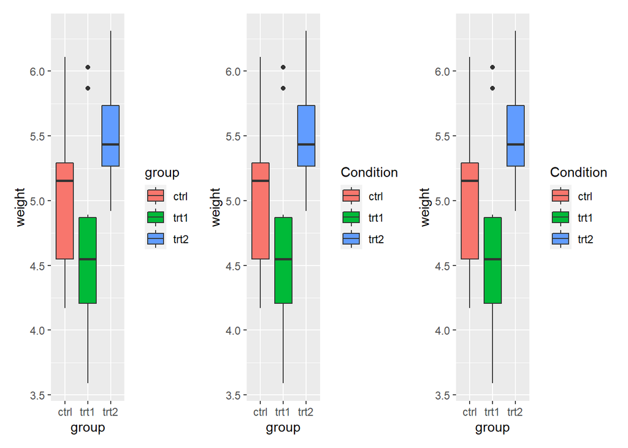

```r
fig_10081 <-
  PlantGrowth %>%
  ggplot(aes(x = group, y = weight, fill = group)) +
  geom_boxplot()

fig_10082 <-
  PlantGrowth %>%
  ggplot(aes(x = group, y = weight, fill = group)) +
  geom_boxplot() +
  labs(fill = "Condition")

fig_10083 <-
  PlantGrowth %>%
  ggplot(aes(x = group, y = weight, fill = group)) +
  geom_boxplot() +
  scale_fill_discrete(name = "Condition")

fig_10081 + fig_10082 + fig_10083
```

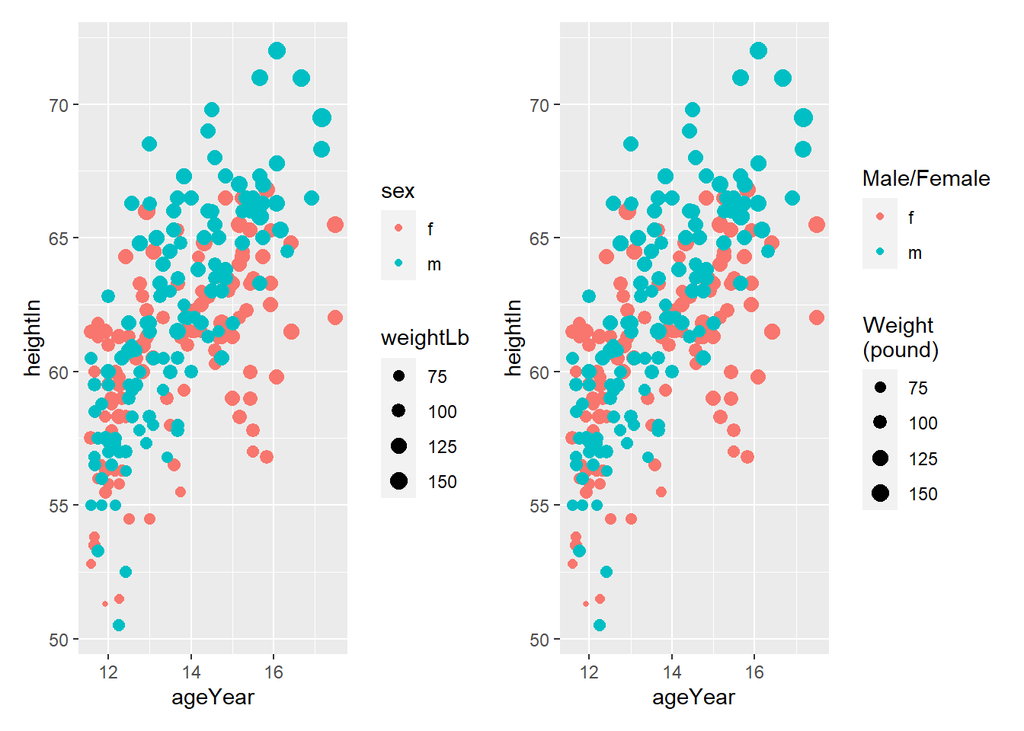

```r
fig_10091 <-
  heightweight %>%
  ggplot(aes(x = ageYear, y = heightIn, color = sex)) +
  geom_point(aes(size = weightLb)) +
  scale_size_continuous(range = c(1,4))

fig_10092 <-
  heightweight %>%
  ggplot(aes(x = ageYear, y = heightIn, color = sex)) +
  geom_point(aes(size = weightLb)) +
  scale_size_continuous(range = c(1,4)) +
  labs(color = "Male/Female", size = "Weight\n(pound)")

fig_10091 + fig_10092
```

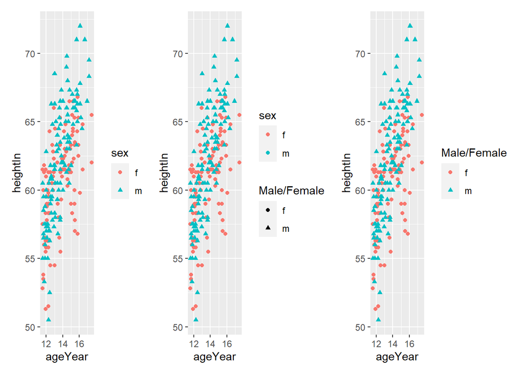

```r
fig_10101 <-
  heightweight %>%
  ggplot(aes(x = ageYear, y = heightIn, shape = sex, color = sex)) +
  geom_point()

fig_10102 <-
  heightweight %>%
  ggplot(aes(x = ageYear, y = heightIn, shape = sex, color = sex)) +
  geom_point() +
  labs(shape = "Male/Female")

fig_10103 <-
  heightweight %>%
  ggplot(aes(x = ageYear, y = heightIn, shape = sex, color = sex)) +
  geom_point() +
  labs(shape = "Male/Female", color = "Male/Female" )

fig_10101 + fig_10102 + fig_10103
```

### 10.6 Changing the appearance of a legend title

legend tile을 변경하기 위해서는 `theme(legend.title = element_text())`를 사용함.

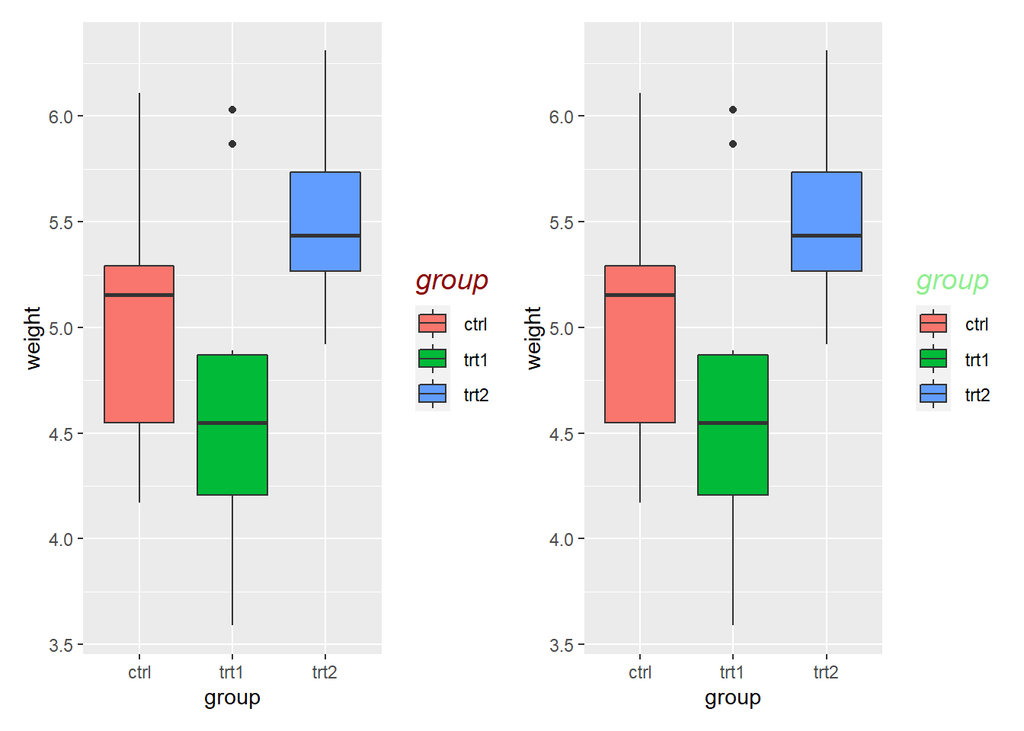

```r
fig_10111 <-
  PlantGrowth %>%
  ggplot(aes(x = group, y = weight, fill = group)) +
  geom_boxplot() +
  theme(legend.title = element_text(face = "italic", family = "sans",
                                    color = "#8B0000", size = 14))

fig_10112 <-
  PlantGrowth %>%
  ggplot(aes(x = group, y = weight, fill = group)) +
  geom_boxplot() +
  guides(fill = guide_legend(title.theme =
                               element_text(face = "italic",family = "sans",
                                            color = "#90ee90", size = 14)))


fig_10111 + fig_10112
```

### 10.7 Removing a legend title

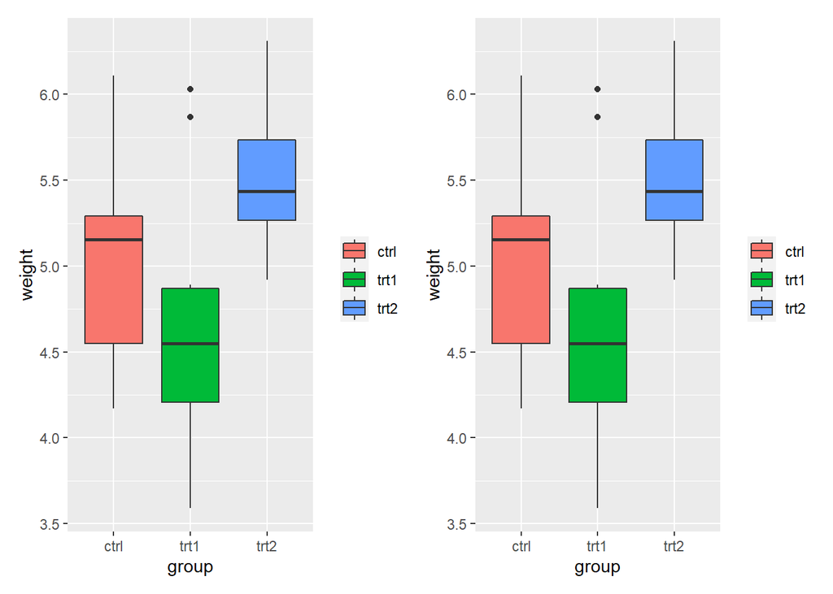

```r
fig_10121 <-
  PlantGrowth %>%
  ggplot(aes(x = group, y = weight, fill = group)) +
  geom_boxplot() +
  guides(fill = guide_legend(title = NULL))

fig_10122 <-
  PlantGrowth %>%
  ggplot(aes(x = group, y = weight, fill = group)) +
  geom_boxplot() +
  scale_fill_hue(guide = guide_legend(title = NULL))

fig_10121 + fig_10122
```

### 10.8 Changing the labels in a legend

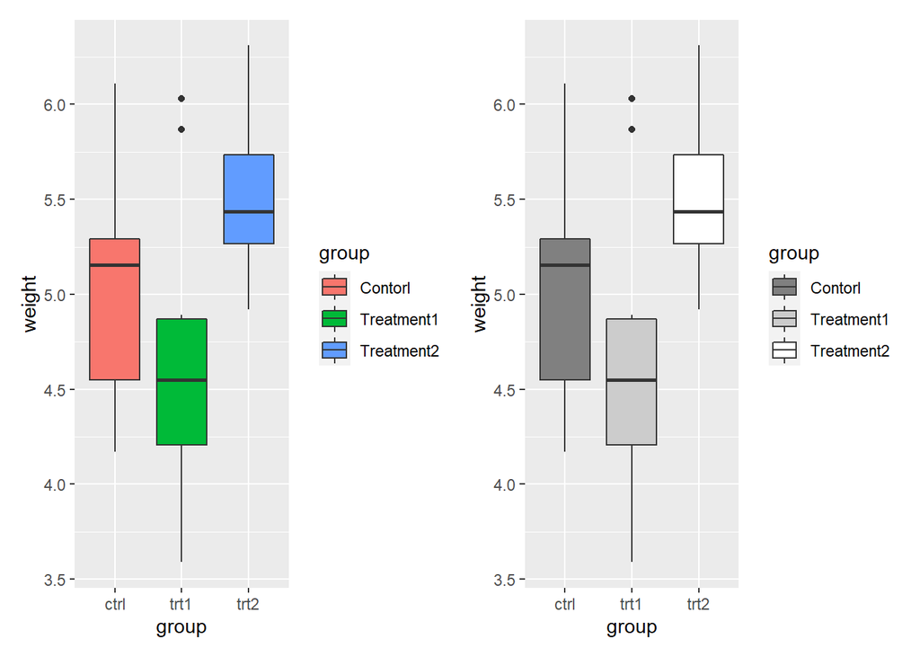

```r
fig_10131 <-
  PlantGrowth %>%
  ggplot(aes(x = group, y = weight, fill = group)) +
  geom_boxplot() +
  scale_fill_discrete(labels = c("Contorl", "Treatment1", "Treatment2"))

fig_10132 <-
  PlantGrowth %>%
  ggplot(aes(x = group, y = weight, fill = group)) +
  geom_boxplot() +
  scale_fill_grey(start = 0.5, end = 1.0,
                  labels=c("Contorl", "Treatment1", "Treatment2"))

fig_10131 + fig_10132
```

만약 legend item의 순설르 변경하면 label도 동일한 순서로 바꿔줘야 한다.

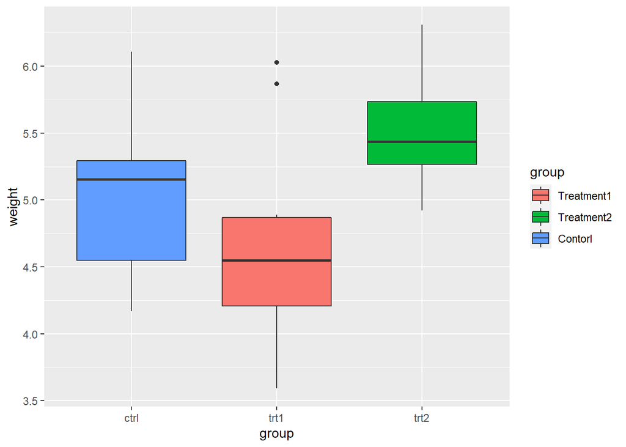

```r
PlantGrowth %>%
  ggplot(aes(x = group, y = weight, fill = group)) +
  geom_boxplot() +
  scale_fill_discrete(limits = c("trt1", "trt2", "ctrl"),
                      labels = c("Treatment1", "Treatment2", "Contorl"))
```

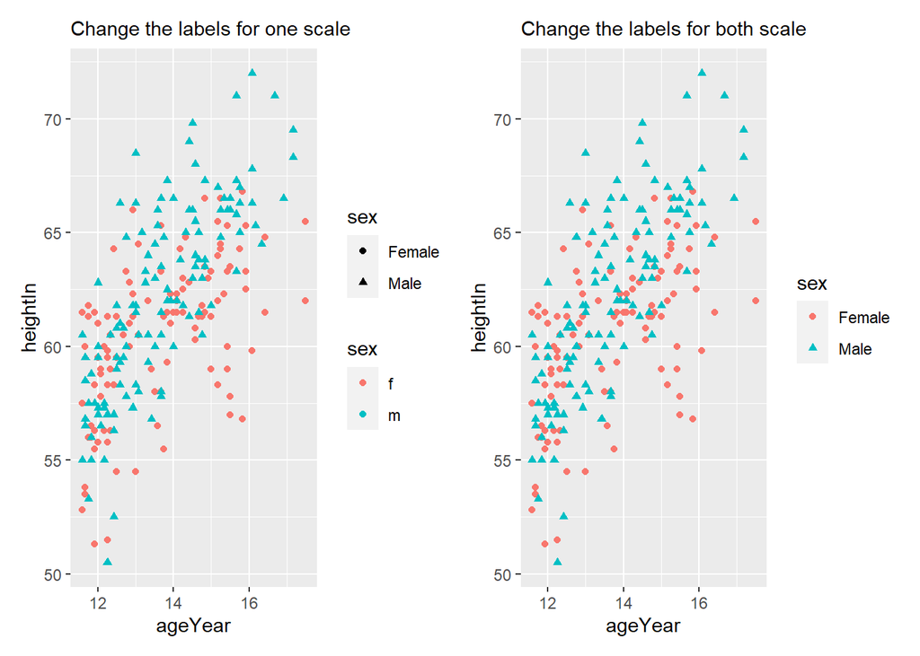

```r
fig_10151 <-
  heightweight %>%
  ggplot(aes(x = ageYear, y = heightIn, shape = sex, color = sex)) +
  geom_point() +
  scale_shape_discrete(labels = c("Female", "Male")) +
  labs(subtitle = "Change the labels for one scale")

fig_10152 <-
  heightweight %>%
  ggplot(aes(x = ageYear, y = heightIn, shape = sex, color = sex)) +
  geom_point() +
  scale_shape_discrete(labels = c("Female", "Male")) +
  scale_color_discrete(labels = c("Female", "Male")) +
  labs(subtitle = "Change the labels for both scale")

fig_10151 + fig_10152
```

### 10.9 Changing the appearance of legend labels

legend labels을 변경하기 위해서는 `theme(legend.text = element_text())`를 사용한다.

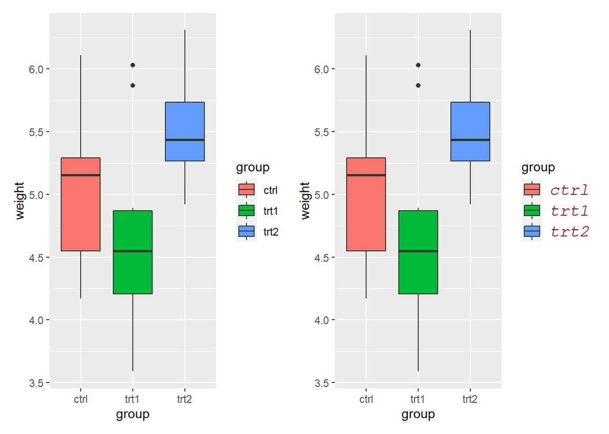

```r
fig_10161 <-
  PlantGrowth %>%
  ggplot(aes(x = group, y = weight, fill = group)) +
  geom_boxplot()

fig_10162 <-
  PlantGrowth %>%
  ggplot(aes(x = group, y = weight, fill = group)) +
  geom_boxplot() +
  theme(legend.text = element_text(face = "italic", family = "mono",
                                   color = "#8B0000", size = 14))

fig_10161 + fig_10162
```

### 10.10 Using labels with multiple lines of text

legend의 label을 한줄이상 쓰게 되면 서로 겹치는 현상이 발생함.  
이를 해결하기 위해서 legend key의 높이를 증가시키고 줄 사이 공간을 줄여야 함.  
높이를 설정하기 위해서 `grid`package의 `unit()`을 사용함.

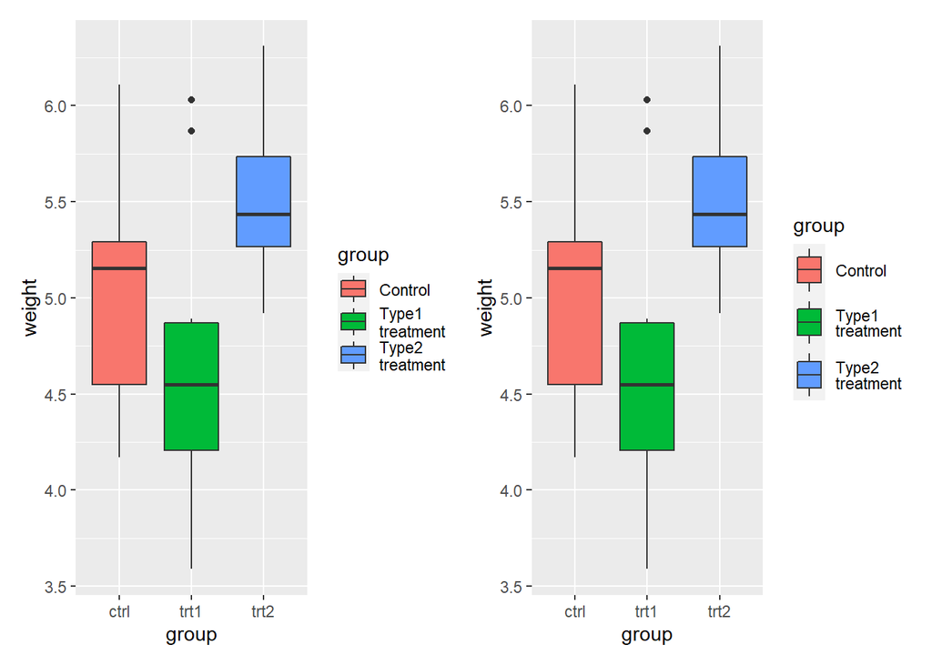

```r
fig_10171 <-
  PlantGrowth %>%
  ggplot(aes(x = group, y = weight, fill = group)) +
  geom_boxplot() +
  scale_fill_discrete(labels = c("Control", "Type1\ntreatment", "Type2\ntreatment"))

fig_10172 <-
  PlantGrowth %>%
  ggplot(aes(x = group, y = weight, fill = group)) +
  geom_boxplot() +
  scale_fill_discrete(labels = c("Control", "Type1\ntreatment", "Type2\ntreatment")) +
  theme(legend.text = element_text(lineheight = 0.8),
        legend.key.height = grid::unit(1, "cm"))


fig_10171 + fig_10172
```

**END**